# Computational Lab Notebook

## 5. Analysis

Read the counts and normalize the focal gene:

```r
local_paths <- c(
  "Data_Folder/Stickle_RNAseq.tsv",
  "../Data_Folder/Stickle_RNAseq.tsv"
)
found <- local_paths[file.exists(local_paths)]
data_file <- if (length(found) > 0) {
  found[1]
} else {
  "https://wcresko.github.io/BioE_Comp_Tools_Fa2026/Data_Folder/Stickle_RNAseq.tsv"
}

stickle <- read_tsv(data_file, show_col_types = FALSE) |>
  mutate(lib_size = rowSums(across(starts_with("Gene"))))

focal <- stickle |>
  transmute(
    Individual, Genotype, Microbiota,
    gene369 = log2(Gene369 / lib_size * 1e6 + 1)
  )

count(focal, Genotype, Microbiota)
```

| Genotype | Microbiota | n |
| --- | --- | --- |
| A | conventional | 20 |
| A | mono | 20 |
| B | conventional | 20 |
| B | mono | 20 |

Visualize expression by group before modeling:

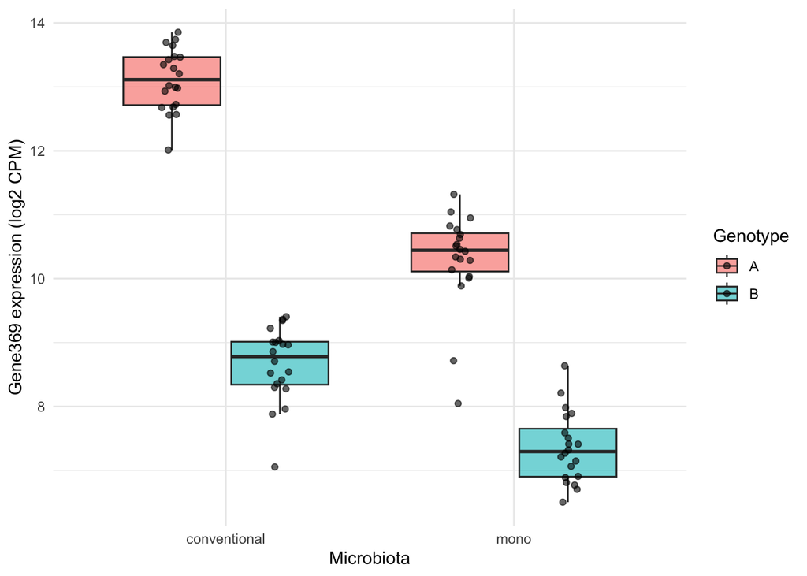

Figure 1: Gene369 expression (log2 CPM) by genotype and microbiota treatment.

```r
ggplot(focal, aes(x = Microbiota, y = gene369, fill = Genotype)) +
  geom_boxplot(outlier.shape = NA, alpha = 0.6) +
  geom_point(
    position = position_jitterdodge(jitter.width = 0.15),
    size = 1.5, alpha = 0.6
  ) +
  labs(y = "Gene369 expression (log2 CPM)") +
  theme_minimal()
```

Fit the two-factor model with interaction:

```r
fit <- lm(gene369 ~ Genotype * Microbiota, data = focal)
summary(fit)
```

```
Call:
lm(formula = gene369 ~ Genotype * Microbiota, data = focal)

Residuals:
     Min       1Q   Median       3Q      Max
-2.25003 -0.31706  0.05213  0.36281  1.28271

Coefficients:
                         Estimate Std. Error t value Pr(>|t|)
(Intercept)               13.1149     0.1347  97.332  < 2e-16 ***
GenotypeB                 -4.4562     0.1906 -23.385  < 2e-16 ***
Microbiotamono            -2.8192     0.1906 -14.795  < 2e-16 ***
GenotypeB:Microbiotamono   1.5139     0.2695   5.618 3.03e-07 ***
---
Signif. codes:  0 '***' 0.001 '**' 0.01 '*' 0.05 '.' 0.1 ' ' 1

Residual standard error: 0.6026 on 76 degrees of freedom
Multiple R-squared:  0.9306,    Adjusted R-squared:  0.9279
F-statistic: 339.8 on 3 and 76 DF,  p-value: < 2.2e-16
```

```r
anova(fit)
```

|  | Df | Sum Sq | Mean Sq | F value | Pr(>F) |
| --- | --- | --- | --- | --- | --- |
| Genotype | 1 | 273.68711 | 273.6871108 | 753.6997 | 3.406657e-41 |
| Microbiota | 1 | 85.05878 | 85.0587803 | 234.2411 | 6.392570e-25 |
| Genotype:Microbiota | 1 | 11.45993 | 11.4599300 | 31.5592 | 3.034937e-07 |
| Residuals | 76 | 27.59749 | 0.3631249 | NA | NA |

Check the residuals:

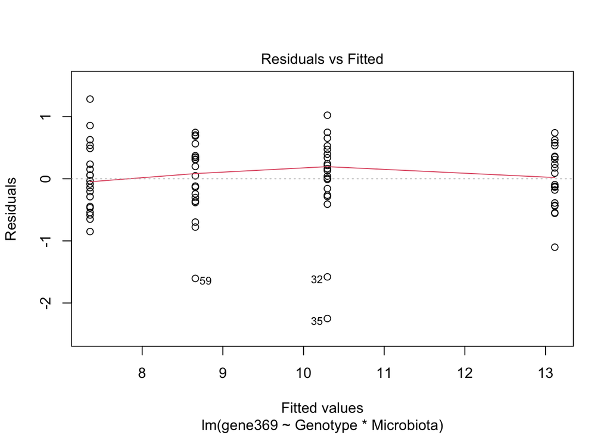

Figure 2: Residuals vs. fitted values for the two-factor model.

```r
plot(fit, which = 1)
```

## 6. Results and interpretation

Both main effects and the interaction are significant. Genotype B fish express Gene369 about 4.5 log2 CPM units lower than genotype A (p < 1e-30), mono-association lowers expression by about 2.8 units in genotype A (p < 1e-20), and the positive interaction term (+1.5, p = 3e-7) means the microbiota effect is weaker in genotype B. The model explains ~93% of the variance. Interpretation: the transcriptional response of Gene369 to microbiota depends on host genotype — a candidate for genotype-by-environment interaction.

## 7. Problems and dead ends

Raw counts were initially modeled without normalization; library sizes vary ~4.6-fold across fish, which inflated the residual variance. Switched to log2 CPM.

## 8. Next steps

- Repeat the model across all 600 genes; adjust p-values (FDR).
- Check whether Gene369’s co-expression partners (e.g. Gene208) show the same interaction pattern.